# Classification with Bayesian Approach

Vedant Kansara

2022-12-13

## Load Packages

```r
library(tidyverse)
```

## Read Data

```r
df <- readr::read_csv('fall2022_finalproject.csv', col_names = TRUE)
```

**Making data frame for derived inputs**

```r
df_derived <- df %>%
  mutate(x5 = 1 - (x1 + x2 + x3 + x4),
         w = x2 / (x3 + x4),
         z = (x1 + x2) / (x4 + x5),
         t = v1 * v2)
```

**Changing the output response**

```r
df_cat <- df %>%
  mutate(outcome = ifelse(output < 0.33, 1, 0)) %>%
  select(-output)
```

```r
df_derived_cat <- df_derived %>%
  mutate(outcome = ifelse(output < 0.33, 1, 0)) %>%
  select(-output)
```

**Transforming the variables based on EDA**

```r
lambda_x2 <- forecast::BoxCox.lambda(df_cat$x2, lower = -5, upper = 5)
df_t <- df_cat %>%
  mutate(x2 = forecast::BoxCox(x2, lambda = lambda_x2))
```

**Scaling the variables**

```r
df_scaled <- df_t %>%
  select(-m) %>%
  select(-outcome) %>%
  scale(center = TRUE, scale = TRUE) %>%
  as.data.frame() %>%
  mutate(m = df$m,
         outcome = df_cat$outcome)

df_scaled %>% glimpse()
```

```
## Rows: 1,252
## Columns: 11
## $ x1      <dbl> -1.5738847, -1.5417248, -1.6169814, 0.2697741, -1.5382524, -1.…
## $ x2      <dbl> 0.8183291, 0.8414672, -1.5255758, -1.1311348, 0.8323620, -1.30…
## $ x3      <dbl> 1.868404e+00, 1.914109e+00, -3.502472e-02, -5.917579e-02, 1.39…
## $ x4      <dbl> -1.55449373, 0.09960806, -1.56780070, 0.11541489, 0.13095250, …
## $ v1      <dbl> -1.778004334, -1.753001876, -0.029998561, 0.003920736, -0.0179…
## $ v2      <dbl> -1.71527049, -1.73929008, -1.72768396, -1.64701100, 0.05303922…
## $ v3      <dbl> -1.776593748, -1.738517193, -1.723302711, -1.713731621, -1.695…
## $ v4      <dbl> -0.35448100, 0.73932327, -0.33537921, 0.68743462, 0.18120289, …
## $ v5      <dbl> -1.5262542, -0.8573905, -1.5594583, -1.4301529, 0.1670227, -1.…
## $ m       <chr> "A", "A", "A", "A", "A", "A", "A", "A", "A", "A", "A", "A", "A…
## $ outcome <dbl> 0, 0, 0, 1, 0, 0, 0, 0, 0, 0, 0, 1, 0, 0, 0, 1, 1, 1, 0, 0, 0,…
```

```r
df_derived_scaled <- df_derived_cat %>%
  select(-m) %>%
  select(-outcome) %>%
  scale(center = TRUE, scale = TRUE) %>%
  as.data.frame() %>%
  mutate(m = df$m,
         outcome = df_derived_cat$outcome)
```

**Making the Design Matrix for mod-7 and mod-8**

We are choosing model-8 because it is the best model of all glm, and model-7 because it is the second best model. Also we chose model-7 because the formulation of model-7 and model-8 is similar just with model-7 we have used the base features set and with model-8 we are using the expanded features set.

```r
Xmod7 <- model.matrix(outcome ~ splines::ns(x1, df = 4) +
                      splines::ns(x2, df = 4) +
                      splines::ns(x3, df = 4) +
                      splines::ns(x4, df = 4) +
                      splines::ns(v1, df = 4) +
                      splines::ns(v2, df = 4) +
                      splines::ns(v3, df = 4) +
                      splines::ns(v4, df = 4) +
                      splines::ns(v5, df = 4) +
                        m, data = df_scaled)
```

```r
Xmod8 <- model.matrix(outcome ~ splines::ns(x4, df = 4) +
                        splines::ns(x5, df = 4) +
                        splines::ns(v1, df = 4) +
                        splines::ns(v3, df = 4) +
                        splines::ns(v4, df = 4) +
                        splines::ns(v5, df = 4) +
                        splines::ns(w, df = 4) +
                        splines::ns(z, df = 4) +
                        splines::ns(t, df = 4) +
                        m, data = df_derived_scaled)
```

**Creating the information list**

```r
info_mod7 <- list(
  yobs = df_scaled$outcome,
  design_matrix = Xmod7,
  mu_beta = 0,
  tau_beta = 1.5
)
```

```r
info_mod7_weak <- list(
  yobs = df_scaled$outcome,
  design_matrix = Xmod7,
  mu_beta = 0,
  tau_beta = 15
)
```

```r
info_mod8 <- list(
  yobs = df_derived_scaled$outcome,
  design_matrix = Xmod8,
  mu_beta = 0,
  tau_beta = 1.5
)
```

```r
info_mod8_weak <- list(
  yobs = df_derived_scaled$outcome,
  design_matrix = Xmod8,
  mu_beta = 0,
  tau_beta = 15
)
```

##### Log Posterior Function

```r
logistic_logpost <- function(unknowns, my_info)
{
  # Extracting the design matrix
  X <- my_info$design_matrix

  #Calculating Linear Predictor
  eta <- as.vector(X %*% as.matrix(unknowns))

  #Calculating Event Probability
  mu <- boot::inv.logit(eta)

  #Evaluating the likelihood
  log_lik <- sum(dbinom(x = my_info$yobs,
                        size = 1,
                        prob = mu,
                        log = TRUE))

  #Evaluating log-prior
  log_prior <- sum(dnorm(x = unknowns,
                         mean = my_info$mu_beta,
                         sd = my_info$tau_beta,
                         log = TRUE))

  #Summing Together
  log_lik + log_prior
}
```

##### Laplace Function

```r
my_laplace <- function(start_guess, logpost_func, ...)
{
  # code adapted from the `LearnBayes`` function `laplace()`
  fit <- optim(start_guess,
               logpost_func,
               gr = NULL,
               ...,
               method = "BFGS",
               hessian = TRUE,
               control = list(fnscale = -1, maxit = 5001))

  mode <- fit$par
  post_var_matrix <- -solve(fit$hessian)
  p <- length(mode)
  int <- p/2 * log(2 * pi) + 0.5 * log(det(post_var_matrix)) + logpost_func(mode, ...)
  # package all of the results into a list
  list(mode = mode,
       var_matrix = post_var_matrix,
       log_evidence = int,
       converge = ifelse(fit$convergence == 0,
                         "YES",
                         "NO"),
       iter_counts = as.numeric(fit$counts[1]))
}
```

```r
laplace_7_weak <- my_laplace(rep(0, ncol(Xmod7)), logistic_logpost, info_mod7_weak)

laplace_7_weak$converge
```

```
## [1] "YES"
```

```r
laplace_7 <- my_laplace(rep(0, ncol(Xmod7)), logistic_logpost, info_mod7)

laplace_7$converge
```

```
## [1] "YES"
```

```r
laplace_8_weak <- my_laplace(rep(0, ncol(Xmod8)), logistic_logpost, info_mod8_weak)

laplace_8_weak$converge
```

```
## [1] "YES"
```

```r
laplace_8 <- my_laplace(rep(0, ncol(Xmod8)), logistic_logpost, info_mod8)

laplace_8$converge
```

```
## [1] "YES"
```

**Checking which model is best using Evidence based approach**

```r
mod_log_evidences <- purrr::map_dbl(list(laplace_7_weak, laplace_7, laplace_8_weak, laplace_8),
                                     'log_evidence')

all_model_weights <- exp( mod_log_evidences ) / sum(exp(mod_log_evidences))
```

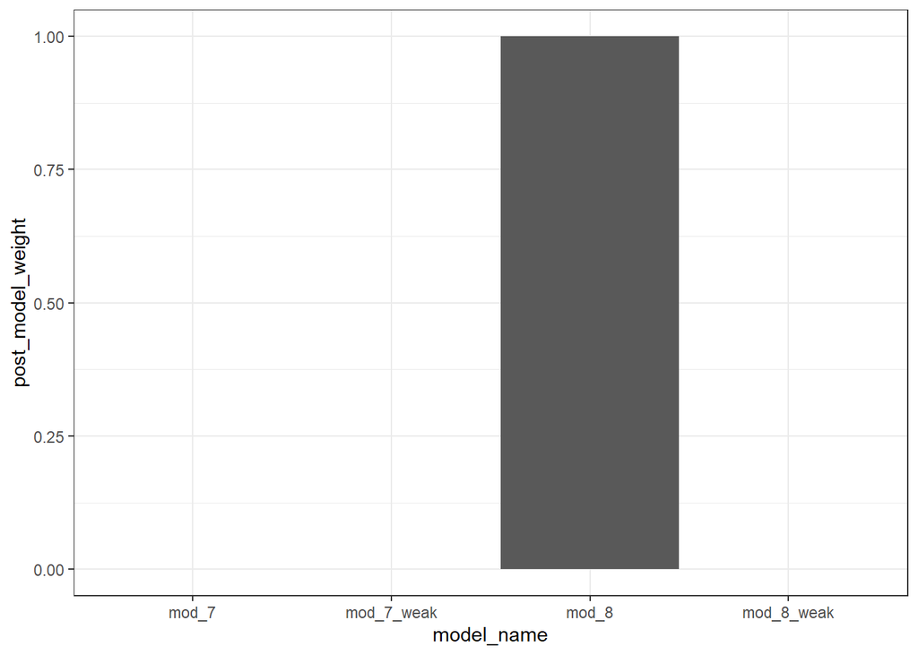

```r
tibble::tibble(
  model_name = c("mod_7_weak", "mod_7", "mod_8_weak", "mod_8"),
  post_model_weight = all_model_weights
) %>%
  ggplot(mapping = aes(x = model_name, y = post_model_weight)) +
  geom_bar(stat = 'identity') +
  coord_cartesian(ylim = c(0,1)) +
  theme_bw()
```

**We see that model-8 is the best model.**

**Visualizing Posterior Summary**

**Creating a function which creates coefficient summary plot**

```r
viz_post_coef <- function(post_means, post_sds, xnames)
{
  tibble::tibble(
    mu = post_means,
    sd = post_sds,
    x = xnames
  ) %>%
    mutate(x = factor(x, levels = xnames)) %>%
    ggplot(mapping = aes(x = x)) +
    geom_hline(yintercept = 0, color = "grey", linetype = "dashed") +
    geom_point(mapping = aes(y = mu)) +
    geom_linerange(mapping = aes(ymin = mu - 2 * sd,
                                 ymax = mu + 2 * sd,
                                 group = x)) +
    labs(x = 'feature', y = 'coefficient value') +
    coord_flip() +
    theme_bw()
}
```

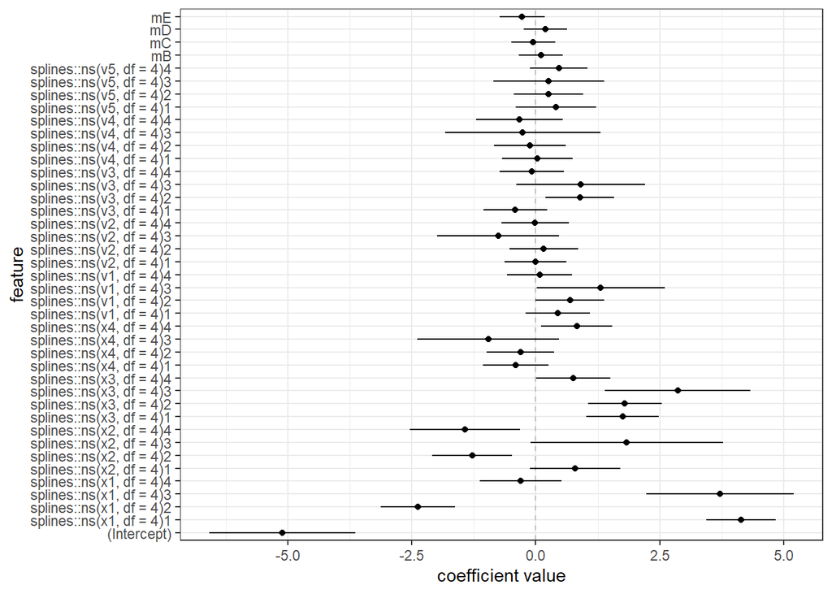

```r
viz_post_coef(laplace_7$mode[1:ncol(Xmod7)],
              sqrt(diag(laplace_7$var_matrix)[1:ncol(Xmod7)]),
              colnames(Xmod7))
```

From coef-summary of model-7 it looks like x1 and x3 are most important variables.

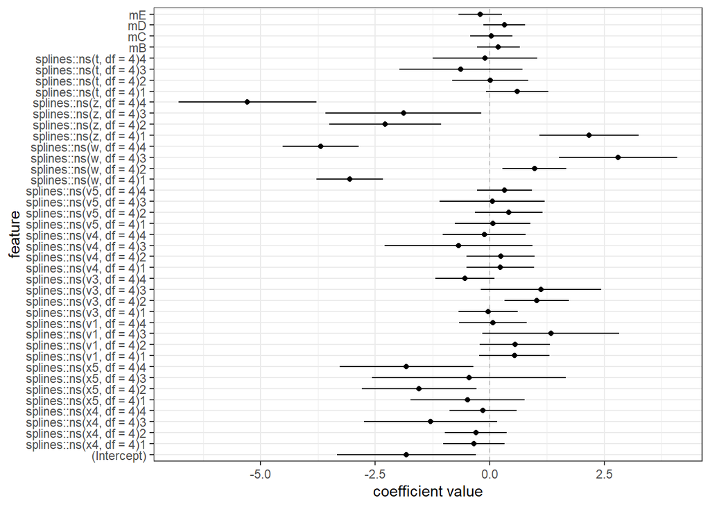

```r
viz_post_coef(laplace_8$mode[1:ncol(Xmod8)],
              sqrt(diag(laplace_8$var_matrix)[1:ncol(Xmod8)]),
              colnames(Xmod8))
```

From the above figure we can see that z is the most significant variable and w is the second most significant variable.

```r
viz_grid <- expand.grid(x1 = seq(min(df_derived_scaled$x1), max(df_derived_scaled$x1), length.out = 5),
                        x2 = median(df_derived_scaled$x2),
                        x3 = median(df_derived_scaled$x3),
                        x4 = median(df_derived_scaled$x4),
                        x5 = median(df_derived_scaled$x5),
                        v1 = median(df_derived_scaled$v1),
                        v2 = median(df_derived_scaled$v2),
                        v3 = median(df_derived_scaled$v3),
                        v4 = median(df_derived_scaled$v4),
                        v5 = median(df_derived_scaled$v5),
                        w = seq(min(df_derived_scaled$w), max(df_derived_scaled$w), length.out = 5),
                        z = seq(min(df_derived_scaled$z), max(df_derived_scaled$z), length.out = 101),
                        t = median(df_derived_scaled$t),
                        m = unique(df_derived_scaled$m),
                        KEEP.OUT.ATTRS = FALSE,
                        stringsAsFactors = FALSE) %>%
  as.data.frame() %>% tibble::as_tibble()

viz_grid %>% glimpse()
```

```
## Rows: 12,625
## Columns: 14
## $ x1 <dbl> -1.7235758, -0.7272544, 0.2690671, 1.2653885, 2.2617099, -1.7235758…
## $ x2 <dbl> 0.109188, 0.109188, 0.109188, 0.109188, 0.109188, 0.109188, 0.10918…
## $ x3 <dbl> 0.007119913, 0.007119913, 0.007119913, 0.007119913, 0.007119913, 0.…
## $ x4 <dbl> 0.1012426, 0.1012426, 0.1012426, 0.1012426, 0.1012426, 0.1012426, 0…
## $ x5 <dbl> -0.3858426, -0.3858426, -0.3858426, -0.3858426, -0.3858426, -0.3858…
## $ v1 <dbl> 0.02131527, 0.02131527, 0.02131527, 0.02131527, 0.02131527, 0.02131…
## $ v2 <dbl> 0.04371815, 0.04371815, 0.04371815, 0.04371815, 0.04371815, 0.04371…
## $ v3 <dbl> 0.02532552, 0.02532552, 0.02532552, 0.02532552, 0.02532552, 0.02532…
## $ v4 <dbl> -0.008900144, -0.008900144, -0.008900144, -0.008900144, -0.00890014…
## $ v5 <dbl> 0.179781, 0.179781, 0.179781, 0.179781, 0.179781, 0.179781, 0.17978…
## $ w  <dbl> -1.78839938, -1.78839938, -1.78839938, -1.78839938, -1.78839938, -0…
## $ z  <dbl> -1.461784, -1.461784, -1.461784, -1.461784, -1.461784, -1.461784, -…
## $ t  <dbl> -0.08333946, -0.08333946, -0.08333946, -0.08333946, -0.08333946, -0…
## $ m  <chr> "A", "A", "A", "A", "A", "A", "A", "A", "A", "A", "A", "A", "A", "A…
```

```r
generate_glm_post_samples <- function(mvn_result, num_samples)
{
  # specify the number of unknown beta parameters
  length_beta <- length(mvn_result$mode)

  # generate the random samples
  beta_samples <- MASS::mvrnorm(n = num_samples,
                                mu = mvn_result$mode,
                                Sigma = mvn_result$var_matrix)

  # change the data type and name
  beta_samples %>%
    as.data.frame() %>% tibble::as_tibble() %>%
    purrr::set_names(sprintf("beta_%02d", (1:length_beta) - 1))
}
```

```r
post_logistic_pred_samples <- function(Xnew, Bmat)
{
  # calculate the linear predictor at all prediction points and posterior samples
  eta_mat <- Xnew %*% t(Bmat)

  # calculate the event probability
  mu_mat <- boot::inv.logit(eta_mat)

  # book keeping
  list(eta_mat = eta_mat, mu_mat = mu_mat)
}
```

```r
summarize_logistic_pred_from_laplace <- function(mvn_result, Xtest, num_samples)
{
  # generate posterior samples of the beta parameters
  betas <- generate_glm_post_samples(mvn_result, num_samples)

  # data type conversion
  betas <- as.matrix(betas)

  # make posterior predictions on the test set
  pred_test <- post_logistic_pred_samples(Xtest, betas)

  # calculate summary statistics on the posterior predicted probability
  # summarize over the posterior samples

  # posterior mean, should you summarize along rows (rowMeans) or
  # summarize down columns (colMeans) ???
  mu_avg <- rowMeans(pred_test$mu_mat)

  # posterior quantiles
  mu_q05 <- apply(pred_test$mu_mat, 1, stats::quantile, probs = 0.05)
  mu_q95 <- apply(pred_test$mu_mat, 1, stats::quantile, probs = 0.95)

  # book keeping
  tibble::tibble(
    mu_avg = mu_avg,
    mu_q05 = mu_q05,
    mu_q95 = mu_q95
  ) %>%
    tibble::rowid_to_column("pred_id")
}
```

**Function to create spline knots**

```r
make_splines_training_knots <- function(J, train_data, xname)
{
  x <- train_data %>% select(all_of(xname)) %>% pull()

  train_basis <- splines::ns(x, df = J)

  as.vector(attributes(train_basis)$knots)
}
```

**Function to create boundary knots**

```r
make_splines_boundary_knots <- function(J, train_data, xname)
{
  x <- train_data %>% select(all_of(xname)) %>% pull()

  train_basis <- splines::ns(x, df = J)

  as.vector(attributes(train_basis)$Boundary.knots)
}
```

**Creating spline knots for model-7**

```r
x1_spline_knots7 <- make_splines_training_knots(4, df_derived_scaled, as.character("x1"))
x2_spline_knots7 <- make_splines_training_knots(4, df_derived_scaled, as.character("x2"))
x3_spline_knots7 <- make_splines_training_knots(4, df_derived_scaled, as.character("x3"))
x4_spline_knots7 <- make_splines_training_knots(4, df_derived_scaled, as.character("x4"))

v1_spline_knots7 <- make_splines_training_knots(4, df_derived_scaled, as.character("v1"))
v2_spline_knots7 <- make_splines_training_knots(4, df_derived_scaled, as.character("v2"))
v3_spline_knots7 <- make_splines_training_knots(4, df_derived_scaled, as.character("v3"))
v4_spline_knots7 <- make_splines_training_knots(4, df_derived_scaled, as.character("v4"))
v5_spline_knots7 <- make_splines_training_knots(4, df_derived_scaled, as.character("v5"))
```

**Creating boundary knots for model-7**

```r
x1_bknots7 <- make_splines_boundary_knots(4, df_derived_scaled, as.character("x1"))
x2_bknots7 <- make_splines_boundary_knots(4, df_derived_scaled, as.character("x2"))
x3_bknots7 <- make_splines_boundary_knots(4, df_derived_scaled, as.character("x3"))
x4_bknots7 <- make_splines_boundary_knots(4, df_derived_scaled, as.character("x4"))

v1_bknots7 <- make_splines_boundary_knots(4, df_derived_scaled, as.character("v1"))
v2_bknots7 <- make_splines_boundary_knots(4, df_derived_scaled, as.character("v2"))
v3_bknots7 <- make_splines_boundary_knots(4, df_derived_scaled, as.character("v3"))
v4_bknots7 <- make_splines_boundary_knots(4, df_derived_scaled, as.character("v4"))
v5_bknots7 <- make_splines_boundary_knots(4, df_derived_scaled, as.character("v5"))
```

**Crating design matrix for model-7**

```r
Xviz_7 <- model.matrix( ~ splines::ns(x1, knots = x1_spline_knots7, Boundary.knots = x1_bknots7) +
                          splines::ns(x2, knots = x2_spline_knots7, Boundary.knots = x2_bknots7) +
                          splines::ns(x3, knots = x3_spline_knots7, Boundary.knots = x3_bknots7) +
                          splines::ns(x4, knots = x4_spline_knots7, Boundary.knots = x4_bknots7) +
                          splines::ns(v1, knots = v1_spline_knots7, Boundary.knots = v1_bknots7) +
                          splines::ns(v2, knots = v2_spline_knots7, Boundary.knots = v2_bknots7) +
                          splines::ns(v3, knots = v3_spline_knots7, Boundary.knots = v3_bknots7) +
                          splines::ns(v4, knots = v4_spline_knots7, Boundary.knots = v4_bknots7) +
                          splines::ns(v5, knots = v5_spline_knots7, Boundary.knots = v5_bknots7) +
                          m,
                        data = viz_grid)
```

**Prediction on model-7**

```r
set.seed(7899)

post_pred_summary_7 <- summarize_logistic_pred_from_laplace(laplace_7, Xviz_7, 2500)
```

**Creating spline knots for model-8**

```r
x4_spline_knots <- make_splines_training_knots(4, df_derived_scaled, as.character("x4"))
x5_spline_knots <- make_splines_training_knots(4, df_derived_scaled, as.character("x5"))

v1_spline_knots <- make_splines_training_knots(4, df_derived_scaled, as.character("v1"))
v3_spline_knots <- make_splines_training_knots(4, df_derived_scaled, as.character("v3"))
v4_spline_knots <- make_splines_training_knots(4, df_derived_scaled, as.character("v4"))
v5_spline_knots <- make_splines_training_knots(4, df_derived_scaled, as.character("v5"))

w_spline_knots <- make_splines_training_knots(4, df_derived_scaled, as.character("w"))
z_spline_knots <- make_splines_training_knots(4, df_derived_scaled, as.character("z"))
t_spline_knots <- make_splines_training_knots(4, df_derived_scaled, as.character("t"))
```

**Creating boundary knots for model-8**

```r
x4_bknots <- make_splines_boundary_knots(4, df_derived_scaled, as.character("x4"))
x5_bknots <- make_splines_boundary_knots(4, df_derived_scaled, as.character("x5"))

v1_bknots <- make_splines_boundary_knots(4, df_derived_scaled, as.character("v1"))
v3_bknots <- make_splines_boundary_knots(4, df_derived_scaled, as.character("v3"))
v4_bknots <- make_splines_boundary_knots(4, df_derived_scaled, as.character("v4"))
v5_bknots <- make_splines_boundary_knots(4, df_derived_scaled, as.character("v5"))

w_bknots <- make_splines_boundary_knots(4, df_derived_scaled, as.character("w"))
z_bknots <- make_splines_boundary_knots(4, df_derived_scaled, as.character("z"))
t_bknots <- make_splines_boundary_knots(4, df_derived_scaled, as.character("t"))
```

**Crating design matrix for model-8**

```r
Xviz_8 <- model.matrix( ~ splines::ns(z, knots = z_spline_knots, Boundary.knots = z_bknots) +
                          splines::ns(w, knots = w_spline_knots, Boundary.knots = w_bknots) +
                          splines::ns(t, knots = t_spline_knots, Boundary.knots = t_bknots) +
                          splines::ns(x4, knots = x4_spline_knots, Boundary.knots = x4_bknots) +
                          splines::ns(x5, knots = x5_spline_knots, Boundary.knots = x5_bknots) +
                          splines::ns(v1, knots = v1_spline_knots, Boundary.knots = v1_bknots) +
                          splines::ns(v3, knots = v3_spline_knots, Boundary.knots = v3_bknots) +
                          splines::ns(v4, knots = v4_spline_knots, Boundary.knots = v4_bknots) +
                          splines::ns(v5, knots = v5_spline_knots, Boundary.knots = v5_bknots) +
                          m,
                        data = viz_grid)
```

**Prediction on model-8**

```r
set.seed(7899)

post_pred_summary_8 <- summarize_logistic_pred_from_laplace(laplace_8, Xviz_8, 2500)
```

```r
viz_bayes_logpost_preds <- function(post_pred_summary, input_df)
{
  post_pred_summary %>%
    left_join(input_df %>% tibble::rowid_to_column('pred_id'),
              by = 'pred_id') %>%
    ggplot(mapping = aes(x = z)) +
    geom_ribbon(mapping = aes(ymin = mu_q05,
                              ymax = mu_q95,
                              group = interaction(x1, w, m),
                              fill = m),
                alpha = 0.25) +
    geom_line(mapping = aes(y = mu_avg,
                            group = interaction(x1, w, m),
                            color = m),
              size = 1.15) +
    facet_grid(x1 ~ w, labeller = 'label_both') +
    labs(y = "event probability") +
    theme_bw()
}
```

**Visualizing predictions of model-7**

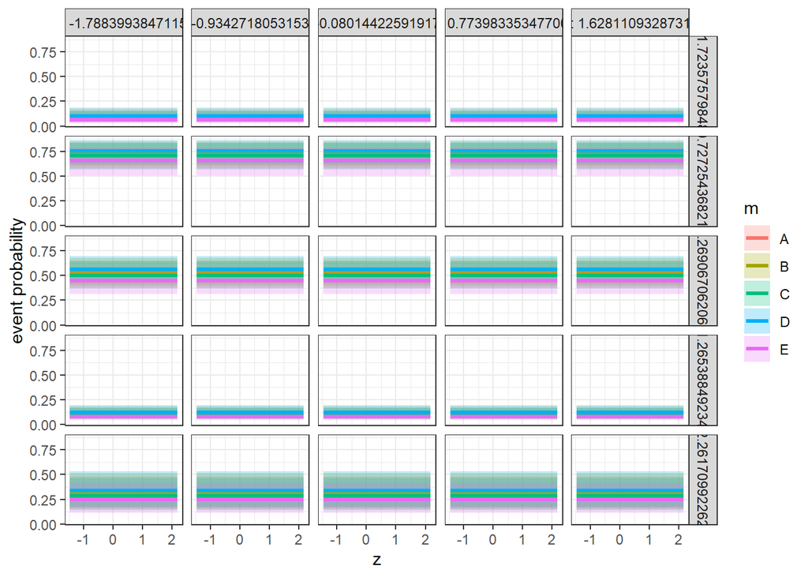

```r
viz_bayes_logpost_preds(post_pred_summary_7, viz_grid)
```

**Visualizing predictions of model-8**

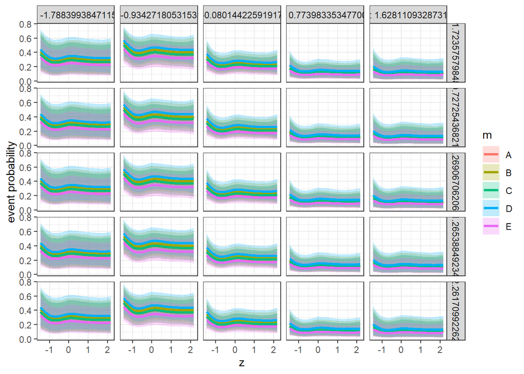

```r
viz_bayes_logpost_preds(post_pred_summary_8, viz_grid)
```